# 2410246_ClinicalModels

Albert Groenendijk

2024-10-26

limma 3.58.1; survival 3.5.8; survminer 0.4.9; slider 0.3.1; RiskRegression 2023.12.21; randomForestSRC 3.3.1; glmnet 4.1.8; gbm 2.2.2

Load libraries

```r
library(tidyverse)
library(survival)
```

```r
library(ggplot2)
library(riskRegression) # for time-dependent AUC calculation
library(randomForestSRC)
library(glmnet) # also loaded as part of riskRegression when you call GLMnet()
library(hal9001) # also loaded as part of riskRegression when you call Hal90001()
```

Define directories

```r
inputdir <- "C:/Users/accou/Documents/PHD_2_projects/7_Predictionmodels_SHMOlink/Input/"
scriptsdir <- "C:/Users/accou/Documents/PHD_2_projects/7_Predictionmodels_SHMOlink/Scripts/"
outputdir <- "C:/Users/accou/Documents/PHD_2_projects/7_Predictionmodels_SHMOlink/Output/"
```

Define generic objects

```r
`%notin%` <- Negate(`%in%`)
```

Set random seed

```r
set.seed(101)
```

Load datasets

```r
train <- readRDS(paste0(outputdir,"clinical_train.rds"))
test <- readRDS(paste0(outputdir,"clinical_test.rds"))
```

Verify data integrity

```r
# Are the column names equal
all(names(train) == names(test))
```

```
## [1] TRUE
```

```r
# Ensure consistent factor levels in both train and test datasets
factor_vars <- c("MALESEX", "IDU", "ORIGIN_NONWESTERN", "SMOKING_NEVER", "baseHCVever", "baseHBVever")

## Convert these variables to factors in both datasets and align levels
for (var in factor_vars) {
  train[[var]] <- factor(train[[var]])
  test[[var]] <- factor(test[[var]], levels = levels(train[[var]]))  # Align levels with training data
}

check_data <- FALSE
if (check_data){
  # Check the data structure for both datasets
  str(train)
  str(test)

  # Identify missingness
  na_counts <- sapply(train, function(x) sum(is.na(x)))
  print(na_counts)

  na_counts <- sapply(test, function(x) sum(is.na(x)))
  print(na_counts)
}
```

# Run univariate Cox regression on train dataset

```r
# First modify AGE and BMI, for which one unit is not so relevant.
## Instead, divide by x so that the HR for a change of x units is determined.
train <- train %>%
  mutate(AGE = AGE / 10,
         baseBMI = baseBMI / 5,
         baseCD4_sqrt = baseCD4_sqrt / 5)

## Leave baseCD4_sqrt as is since this is strongly associated with CD4_LOSS

# Define features (predictors) and outcomes
features <- c("MALESEX", "IDU", "ORIGIN_NONWESTERN", "SMOKING_NEVER","baseVL_log10","baseHCV","baseHBV","baseHCVever","baseHBVever","AGE","baseBMI","baseCD4_sqrt")
outcomes <- c("VL4K","HYBRID", "CD4")

# Frequency of outcome happening
for (outcome in outcomes){
  event <- paste0("EVENT_", outcome)
  print(summary.factor(train[,event]))
}
```

```
## FALSE  TRUE
##   469   376
## FALSE  TRUE
##   294   551
## FALSE  TRUE  NA's
##   406   159   280
```

```r
# Define function to run and clean a univariate cox model for a specific feature and outcome
coxph_singlerow <- function(feature, outcome, dataset){
  # Define the formula for the cox model
  time <- paste0("TIME_", outcome)
  event <- paste0("EVENT_", outcome)
  formula_coxph <- as.formula(paste("Surv(", time, ",", event, ") ~", feature))

  # filter out rows without outcome, only applicable for EVENT_CD4
  dataset <- train %>% filter(!is.na(.data[[event]]))

  # run the univariate model
  model <- coxph(formula_coxph, data = dataset)

  # clean the cox ph model into a tibble
  ## With columns: estimate, std.error, statistic, p.value, conf.low, conf.high
  sumstats <- broom::tidy(model, conf.int = TRUE, exponentiate = TRUE)

  new_row <- tibble(
    Variable = feature,
    Number = sum(!is.na(dataset[[feature]])),
    Outcome = event,
    Analysis = "univariate",
    HR = sumstats$estimate,
    Lower = sumstats$conf.low,
    Upper = sumstats$conf.high,
    Pvalue = sumstats$p.value
  )

  return(new_row)
}

# Example
coxph_singlerow(feature = features[1], outcome = outcomes[1], dataset = dataset)
```

```
## # A tibble: 1 × 8
##   Variable Number Outcome    Analysis      HR Lower Upper  Pvalue
##   <chr>     <int> <chr>      <chr>      <dbl> <dbl> <dbl>   <dbl>
## 1 MALESEX     845 EVENT_VL4K univariate  1.47  1.15  1.88 0.00213
```

```r
# map the coxph_singlerow to every feature and outcome
sumstats_univariate_train <- expand_grid(feature = features, outcome = outcomes) %>%

  # apply to each combination of feature and outcome, storing the result in a list column
  rowwise() %>%
  mutate(result = list(coxph_singlerow(feature, outcome, dataset))) %>%

  # expands the list column into individual columns, effectively joining all the new rows together.
  unnest(result) %>%

  # also add significance levels
  mutate(Significance = case_when(Pvalue < 0.05 & Pvalue > 0.001 ~ "*",
                                               Pvalue < 0.001 & Pvalue > 0.0001 ~ "**",
                                               Pvalue < 0.0001 ~ "***"))

head(sumstats_univariate_train)
```

```
## # A tibble: 6 × 11
##   feature outcome Variable Number Outcome     Analysis    HR Lower Upper  Pvalue
##   <chr>   <chr>   <chr>     <int> <chr>       <chr>    <dbl> <dbl> <dbl>   <dbl>
## 1 MALESEX VL4K    MALESEX     845 EVENT_VL4K  univari… 1.47  1.15  1.88  0.00213
## 2 MALESEX HYBRID  MALESEX     845 EVENT_HYBR… univari… 1.35  1.11  1.64  0.00268
## 3 MALESEX CD4     MALESEX     565 EVENT_CD4   univari… 0.704 0.504 0.984 0.0397
## 4 IDU     VL4K    IDU         845 EVENT_VL4K  univari… 0.774 0.475 1.26  0.302
## 5 IDU     HYBRID  IDU         845 EVENT_HYBR… univari… 0.748 0.493 1.14  0.174
## 6 IDU     CD4     IDU         565 EVENT_CD4   univari… 2.16  1.20  3.90  0.0105
## # ℹ 1 more variable: Significance <chr>
```

## Make forest plot of Cox regression

Create nice labels for outcome measures

```r
sumstats_univariate_train$Outcome <-
  factor(sumstats_univariate_train$Outcome,
         levels = rev(c("EVENT_VL4K","EVENT_HYBRID","EVENT_CD4")),
         labels = rev(c("Viral load > 10,000 copies/mL",
                        "Viral load >10,000 copies/mL
                        \nor >1000 increase in moving median",
                        "CD4 count <500 cells/mm3\nmoving median")))
```

Make forest plot

```r
g <- ggplot(sumstats_univariate_train, aes(HR, Variable, color = Outcome, shape = Outcome)) +
   geom_pointrange(aes(xmin = Lower, xmax = Upper),
                   position = position_dodge(width = 0.5)) +
   geom_vline(xintercept = 1, linetype = 2) +
   theme_bw() +
   theme(strip.placement = "outside",
         strip.text= element_text(angle = 0, size = 6),
         strip.background = element_blank(),
         axis.text = element_text(size = 8, color="black"),
         axis.title = element_text(size = 10, color="black"),
         title = element_text(size=12, color = "black"),
         legend.text = element_text(size = 10, color="black"),
         legend.title = element_text(size = 10, color="black"),
         legend.position = "bottom",
         plot.subtitle = element_text(size = 10, color= "black", face="italic"),
         legend.key.height = unit(1.5,'cm'),
         panel.spacing = unit(0, "mm")) +
   scale_colour_manual(values=rev(c("#5ec962","orange","darkred"))) +
     scale_x_continuous(trans='log10',limits = c(0.1,10))  +
  xlab("Hazard ratio (95% confidence interval)") + ylab("")+
  ggtitle("Baseline predictors for viral or immunological loss",
          subtitle = "Univariate Cox proportional-hazards regression")

g1 <- g +
scale_y_discrete(
  limits = rev(c(
    "AGE", "MALESEX", "baseBMI", "ORIGIN_NONWESTERN",
    "SMOKING_NEVER", "IDU",
    "baseHCVever", "baseHBVever",
    "baseCD4_sqrt", "baseVL_log10")),
  labels = rev(c(
    "Age", "Male sex", "BMI", "Non-Western\ncountry of birth",
    "Never smoked", "Intravenous\ndrug use",
    "History of HCV\nat baseline", "History of HBV\nat baseline",
    "Square root\nCD4 count", "Log10 viral load")))

ggsave(paste0(outputdir, "241027_Univariate_Coxph_Train.pdf"),g1,width = 21/2, height = 29.7/2, units = "cm")
sumstats_univariate_train %>% filter(Pvalue <0.05) %>% arrange(Pvalue)
```

```
## # A tibble: 14 × 11
##    feature   outcome Variable Number Outcome Analysis    HR Lower Upper   Pvalue
##    <chr>     <chr>   <chr>     <int> <fct>   <chr>    <dbl> <dbl> <dbl>    <dbl>
##  1 baseCD4_… CD4     baseCD4…    565 "CD4 c… univari… 0.166 0.129 0.214 3.68e-44
##  2 baseVL_l… HYBRID  baseVL_…    845 "Viral… univari… 2.27  1.97  2.61  1.08e-29
##  3 baseVL_l… VL4K    baseVL_…    845 "Viral… univari… 2.32  1.96  2.76  5.43e-22
##  4 MALESEX   VL4K    MALESEX     845 "Viral… univari… 1.47  1.15  1.88  2.13e- 3
##  5 MALESEX   HYBRID  MALESEX     845 "Viral… univari… 1.35  1.11  1.64  2.68e- 3
##  6 baseCD4_… HYBRID  baseCD4…    839 "Viral… univari… 0.892 0.826 0.963 3.46e- 3
##  7 ORIGIN_N… CD4     ORIGIN_…    565 "CD4 c… univari… 1.52  1.11  2.09  9.00e- 3
##  8 IDU       CD4     IDU         565 "CD4 c… univari… 2.16  1.20  3.90  1.05e- 2
##  9 AGE       HYBRID  AGE         845 "Viral… univari… 0.907 0.837 0.982 1.68e- 2
## 10 baseCD4_… VL4K    baseCD4…    839 "Viral… univari… 0.891 0.808 0.981 1.94e- 2
## 11 baseHCVe… CD4     baseHCV…    565 "CD4 c… univari… 1.85  1.09  3.15  2.38e- 2
## 12 AGE       VL4K    AGE         845 "Viral… univari… 0.899 0.814 0.992 3.42e- 2
## 13 MALESEX   CD4     MALESEX     565 "CD4 c… univari… 0.704 0.504 0.984 3.97e- 2
## 14 baseVL_l… CD4     baseVL_…    565 "CD4 c… univari… 1.27  1.01  1.60  4.16e- 2
## # ℹ 1 more variable: Significance <chr>
```

# Train the multivariate Cox model

```r
# Remove those in train with missing CD4
train <- train %>% filter(!is.na(baseCD4_sqrt))

# Define features (predictors) and outcomes
features <- c("MALESEX", "IDU", "ORIGIN_NONWESTERN", "SMOKING_NEVER","baseVL_log10","baseHCVever","baseHBVever","AGE","baseBMI",
              "baseCD4_sqrt")
outcomes <- c("VL4K","HYBRID", "CD4")

# Frequency of outcome happening
for (outcome in outcomes){
  event <- paste0("EVENT_", outcome)
  print(summary.factor(train[,event]))
}
```

```
## FALSE  TRUE
##   469   370
## FALSE  TRUE
##   294   545
## FALSE  TRUE  NA's
##   406   159   274
```

```r
# Define function to run and clean a univariate cox model for a specific feature and outcome
create_multivar_coxph <- function(features, outcome, dataset){
  # Define the formula for the cox model
  time <- paste0("TIME_", outcome)
  event <- paste0("EVENT_", outcome)
  formula_coxph <- as.formula(paste("Surv(", time, ",", event, ") ~", paste(features, collapse = " + ")))

  model <- coxph(formula_coxph, dataset%>%filter(!is.na(.data[[event]])), x = TRUE)

  return(model)
}

create_multivar_coxph(features, outcomes[1], train)
```

```
## Call:
## coxph(formula = formula_coxph, data = dataset %>% filter(!is.na(.data[[event]])),
##     x = TRUE)
##
##                        coef exp(coef) se(coef)      z        p
## MALESEX1            0.30977   1.36311  0.16557  1.871   0.0614
## IDU1                0.06451   1.06664  0.51340  0.126   0.9000
## ORIGIN_NONWESTERN1 -0.21115   0.80965  0.13706 -1.541   0.1234
## SMOKING_NEVER1     -0.02083   0.97939  0.13374 -0.156   0.8763
## baseVL_log10        0.86658   2.37876  0.11346  7.638 2.21e-14
## baseHCVever1       -0.31078   0.73288  0.43384 -0.716   0.4738
## baseHBVever1        0.03828   1.03902  0.41569  0.092   0.9266
## AGE                -0.06060   0.94120  0.06476 -0.936   0.3494
## baseBMI             0.02092   1.02114  0.07763  0.270   0.7875
## baseCD4_sqrt        0.07736   1.08043  0.06628  1.167   0.2432
##
## Likelihood ratio test=85.34  on 10 df, p=4.477e-14
## n= 638, number of events= 270
##    (201 observations deleted due to missingness)
```

```r
# note that the coxph() is so fast that I do not use the function create_multivar_coxph
## the coxph() model is created as part of obtain_auc
```

Participant counts

```r
train %>% filter(!is.na(baseCD4_sqrt)) %>% count()
```

```
##     n
## 1 839
```

```r
train %>% filter(!is.na(baseCD4_sqrt)) %>% filter(!is.na(EVENT_CD4)) %>% count()
```

```
##     n
## 1 565
```

```r
test %>% filter(!is.na(baseCD4_sqrt)) %>% count()
```

```
##     n
## 1 181
```

```r
test %>% filter(!is.na(baseCD4_sqrt)) %>% filter(!is.na(EVENT_CD4)) %>% count()
```

```
##     n
## 1 138
```

## Improve cox model performance

The problem is that the model was overfitting if I include all predictors, so external testing in test results in AUCs of 0.50.

Only consider the features that were significant in univariate regression: - VL4K & HYBRID –> MALESEX, AGE, VLlog10 and CD4sqrt - CD4 –> MALESEX, VLlog10 and CD4sqrt, IDU, baseHCVever, ORIGIN_NONWESTERN, - time_since_2000 causes strong overfitting probably because interaction terms and should be discarded. - In the RSF very consistently are the most relevant MALESEX, AGE, VLlog10 and CD4sqrt. Regardless of outcome type. Including more does not improve the model, only decreases it. - **Conclusion: best Cox model with only MALESEX, AGE, VLlog10 and CD4sqrt

```r
# Define features (predictors)
features <- c("MALESEX", "AGE",
              #"IDU", "ORIGIN_NONWESTERN", "SMOKING_NEVER", "baseHCVever", "baseHBVever",
              "baseVL_log10", "baseCD4_sqrt"
              )

# Define outcome measures
outcomes <- c("VL4K","HYBRID", "CD4")
# Specify time points of interest to measure AUC

outcome <- outcomes[2]

time <- paste0("TIME_", outcome)
event <- paste0("EVENT_", outcome)
formula_model <- as.formula(paste("Surv(", time, ",", event, ") ~", paste(features, collapse = " + ")))

print(dim(train))
```

```
## [1] 839  19
```

```r
print(dim(test))
```

```
## [1] 181  19
```

```r
# Train the cox model
coxmodel <- create_multivar_coxph(features, outcomes[3], train)

times <- seq(2, 8) * 365
dataset <- test
survformula <- as.formula(paste("Surv(", time, ",", event, ") ~ 1"))
score_result <- Score(list("Cox" = coxmodel),
        formula = survformula,
        data = dataset%>%filter(!is.na(.data[[event]])),
        metrics = "auc",
        summary = "risks",
        times = times)
AUC_overtime <- score_result$AUC$score
AUC_overtime$type <- "test"
print(AUC_overtime)
```

```
##     model times       AUC         se     lower     upper   type
##    <fctr> <num>     <num>      <num>     <num>     <num> <char>
## 1:    Cox   730 0.6599027 0.05130673 0.5593434 0.7604621   test
## 2:    Cox  1095 0.6493616 0.04587759 0.5594432 0.7392801   test
## 3:    Cox  1460 0.6861373 0.04314494 0.6015748 0.7706999   test
## 4:    Cox  1825 0.6682267 0.04463768 0.5807385 0.7557150   test
## 5:    Cox  2190 0.6752950 0.04481797 0.5874534 0.7631366   test
## 6:    Cox  2555 0.6559943 0.05147322 0.5551087 0.7568800   test
## 7:    Cox  2920 0.6014407 0.06609382 0.4718992 0.7309822   test
```

## Penalized cox models

alpha = 1 for lasso, alpha = 0 for ridge

Ridge (L2): Useful when you suspect all variables may be relevant but need regularization. Lasso (L1): Helps with feature selection by pushing less informative coefficients to zero, simplifying the model.

```r
# Define features (predictors)
features <- c("MALESEX", "AGE",
              "IDU", "ORIGIN_NONWESTERN", "SMOKING_NEVER", "baseHCVever", "baseHBVever",
              "baseVL_log10", "baseCD4_sqrt"
              )

# Define outcome measures
outcomes <- c("VL4K","HYBRID", "CD4")
# Specify time points of interest to measure AUC

outcome <- outcomes[1]

time <- paste0("TIME_", outcome)
event <- paste0("EVENT_", outcome)
formula_model <- as.formula(paste("Surv(", time, ",", event, ") ~", paste(features, collapse = " + ")))

print(dim(train))
```

```
## [1] 839  19
```

```r
print(dim(test))
```

```
## [1] 181  19
```

```r
# GLMnet from riskregression is compatible with Score(), but glmnet (lowercase) library is NOT.
# the ?glmnet is very useful for documentation on model parameters.
# alpha = 1 means elasticnet mixing parameter is lasso penalty, and alpha=0 sets it to ridge penalty
train <- train %>% filter(!is.na(baseCD4_sqrt))

penalizedmodel_lasso <- GLMnet(formula_model, data = train, alpha = 1, lambda = NULL, cv = TRUE, nfolds = 10, standardize = TRUE)

na_counts <- sapply(test, function(x) sum(is.na(x)))
print(na_counts)
```

```
##           MALESEX               IDU ORIGIN_NONWESTERN     SMOKING_NEVER
##                 0                 0                 0                 0
##      baseVL_log10           baseHCV           baseHBV       baseHCVever
##                 0                 0                 0                 0
##       baseHBVever               AGE           baseBMI      baseCD4_sqrt
##                 0                 0                23                 0
##   time_since_2000        EVENT_VL4K         TIME_VL4K      EVENT_HYBRID
##                 0                 0                 0                 0
##       TIME_HYBRID         EVENT_CD4          TIME_CD4
##                 0                43                43
```

```r
times <- seq(2, 8) * 365
dataset <- test
survformula <- as.formula(paste("Surv(", time, ",", event, ") ~ 1"))
score_result <- Score(list("Penalized" = penalizedmodel_lasso),
        formula = survformula,
        data = dataset%>%filter(!is.na(.data[[event]])),
        metrics = "auc",
        summary = "risks",
        times = times)
AUC_overtime <- score_result$AUC$score
AUC_overtime$type <- "test"
print(AUC_overtime)
```

```
##        model times       AUC         se     lower     upper   type
##       <fctr> <num>     <num>      <num>     <num>     <num> <char>
## 1: Penalized   730 0.8998826 0.03011460 0.8408591 0.9589062   test
## 2: Penalized  1095 0.8637699 0.03554938 0.7940944 0.9334454   test
## 3: Penalized  1460 0.8655146 0.03447212 0.7979505 0.9330787   test
## 4: Penalized  1825 0.8066632 0.04330435 0.7217882 0.8915381   test
## 5: Penalized  2190 0.7808189 0.04703918 0.6886238 0.8730140   test
## 6: Penalized  2555 0.7489206 0.05740554 0.6364078 0.8614334   test
## 7: Penalized  2920 0.7025343 0.07366500 0.5581535 0.8469150   test
```

## Find optimal alpha for elasticnet

```r
# Define a sequence of alpha values to test
alpha_values <- seq(0, 1, by = 0.1)  # Adjust step size as needed

# Initialize a data frame to store results
elasticnet_cvresults <- data.frame(alpha = numeric(), lambda_min = numeric(), cvm_min = numeric(), outcome = character())

features <- c("MALESEX", "AGE",
              "IDU", "ORIGIN_NONWESTERN", "SMOKING_NEVER", "baseHCVever", "baseHBVever",
              "baseVL_log10", "baseCD4_sqrt"
              )

for (outcome in outcomes){

  time <- paste0("TIME_", outcome)
  event <- paste0("EVENT_", outcome)
  formula_model <- as.formula(paste("Surv(", time, ",", event, ") ~", paste(features, collapse = " + ")))

  # Loop through each alpha value
  for (alpha in alpha_values) {
    # Perform cross-validation for each alpha
    set.seed(123)  # For reproducibility

    penalizedmodel_balanced <- GLMnet(formula_model, data = train, alpha = alpha, lambda = NULL, cv = TRUE, nfolds = 10, standardize = TRUE)

    # Store the results: best lambda and corresponding CV error
    elasticnet_cvresults <- rbind(
      elasticnet_cvresults,
      data.frame(alpha = alpha,
                 lambda_min = penalizedmodel_balanced$fit$lambda.min,
                 cvm_min = min(penalizedmodel_balanced$fit$cvm),
                 outcome = outcome))
  }
}
elasticnet_cvresults
```

```
##    alpha lambda_min  cvm_min outcome
## 1    0.0 0.04538835 13.02334    VL4K
## 2    0.1 0.06285771 13.01837    VL4K
## 3    0.2 0.05004363 13.01463    VL4K
## 4    0.3 0.04018515 13.01257    VL4K
## 5    0.4 0.03307736 13.01163    VL4K
## 6    0.5 0.02904189 13.01104    VL4K
## 7    0.6 0.02420158 13.01070    VL4K
## 8    0.7 0.02276674 13.01044    VL4K
## 9    0.8 0.01992090 13.01024    VL4K
## 10   0.9 0.01770747 13.01012    VL4K
## 11   1.0 0.01749053 13.01002    VL4K
## 12   0.0 0.04865661 12.60265  HYBRID
## 13   0.1 0.06139767 12.59981  HYBRID
## 14   0.2 0.04453876 12.59863  HYBRID
```

[output cut: 19 more lines]

```r
# Find the optimal alpha based on minimum CV error
optimal_alpha_value <- elasticnet_cvresults %>% group_by(outcome) %>% filter(cvm_min == min(cvm_min)) %>% select(alpha, outcome) %>%  pull(alpha, outcome)

print(paste0('optimal alpha for glmnet: ',optimal_alpha_value))
```

```
## [1] "optimal alpha for glmnet: 1" "optimal alpha for glmnet: 1"
## [3] "optimal alpha for glmnet: 1"
```

# Gradient boosted machine

Test the code with simple random data

```r
# Load libraries
library(gbm)
library(riskRegression)
library(survival)  # For Surv function

# Generate sample survival data
set.seed(123)
data <- data.frame(
    time = rexp(100, rate = 0.1),          # Random survival times
    status = rbinom(100, 1, 0.5),          # Random event indicator (1 = event, 0 = censoring)
    x1 = rnorm(100),                       # Predictor 1
    x2 = rnorm(100)                        # Predictor 2
)

# Fit a GBM model with survival data
gbm_model <- gbm(
    formula = Surv(time, status) ~ x1 + x2,  # Survival formula
    data = data,
    distribution = "coxph",                    # Cox model for survival
    n.trees = 100,                           # Number of trees
    interaction.depth = 3,                   # Tree depth
    shrinkage = 0.01,                        # Learning rate
    n.minobsinnode = 10                      # Minimum observations in terminal nodes
)

# Prepare new data for prediction
new_data <- data.frame(x1 = rnorm(10), x2 = rnorm(10))

# Use Score function with the GBM survival model
score_result <- Score(
    list("GBM Model" = gbm_model),
    formula = Surv(time, status) ~ 1,   # Survival formula for Score function
    data = data,                        # Original data with survival info
    times = c(1, 5, 10),                # Time points to evaluate the survival model
    metrics = "AUC",                  # Metric for model evaluation
    summary = "risks"                     # Summary option for integrated Brier score
)

# Print results
AUC_overtime <- score_result$AUC$score
AUC_overtime$type <- "test"
print(AUC_overtime)
```

```
##        model times       AUC         se     lower     upper   type
##       <fctr> <num>     <num>      <num>     <num>     <num> <char>
## 1: GBM Model     1 0.7851391 0.06738809 0.6530609 0.9172173   test
## 2: GBM Model     5 0.6554442 0.06433885 0.5293423 0.7815460   test
## 3: GBM Model    10 0.7557307 0.05496452 0.6480022 0.8634591   test
```

Train the gbm model

```r
# Define features (predictors)
features <- c("MALESEX", "AGE",
              "IDU", "ORIGIN_NONWESTERN", "SMOKING_NEVER", "baseHCVever", "baseHBVever",
              "baseVL_log10", "baseCD4_sqrt"
              )

# Define outcome measures
outcomes <- c("VL4K","HYBRID", "CD4")
# Specify time points of interest to measure AUC

outcome <- outcomes[1]

time <- paste0("TIME_", outcome)
event <- paste0("EVENT_", outcome)
formula_model <- as.formula(paste("Surv(", time, ",", event, ") ~", paste(features, collapse = " + ")))

print(dim(train))
```

```
## [1] 839  19
```

```r
print(dim(test))
```

```
## [1] 181  19
```

```r
train <- train %>% filter(!is.na(baseCD4_sqrt))

# Fit a GBM model with survival data
data <- train
data$time <- data$TIME_VL4K
data$status <- data$EVENT_VL4K
gbm_model <- gbm(
    formula = Surv(time, status) ~ MALESEX + AGE + IDU + ORIGIN_NONWESTERN +
    SMOKING_NEVER + baseHCVever + baseHBVever +
    baseVL_log10 + baseCD4_sqrt,  # Survival formula
    data = data,
    distribution = "coxph",                    # Cox model for survival
    n.trees = 1000,                           # Number of trees
    interaction.depth = 3,                   # Tree depth
    shrinkage = 0.01,                        # Learning rate
    n.minobsinnode = 15,                      # Minimum observations in terminal nodes
    bag.fraction = 0.5 # fraction of training data used for fitting, default 0.5
)

# Test data
test_data <- test
test_data$time <- test_data$TIME_VL4K
test_data$status <- test_data$EVENT_VL4K

# Use Score function with the GBM survival model
times <- seq(2, 8) * 365
survformula <- as.formula(paste("Surv(", time, ",", event, ") ~ 1"))
score_result <- Score(
    list("GBM Model" = gbm_model),
    formula = survformula,   # Survival formula for Score function
    data = data,                        # Original data with survival info
    times = times,                # Time points to evaluate the survival model
    metrics = "AUC",                  # Metric for model evaluation
    summary = "risks"                     # Summary option for integrated Brier score
)

# Print results
AUC_overtime <- score_result$AUC$score
AUC_overtime$type <- "test"
print(AUC_overtime)
```

```
##        model times       AUC         se     lower     upper   type
##       <fctr> <num>     <num>      <num>     <num>     <num> <char>
## 1: GBM Model   730 0.7762458 0.02710459 0.7231218 0.8293698   test
## 2: GBM Model  1095 0.7465529 0.02232687 0.7027931 0.7903128   test
## 3: GBM Model  1460 0.7692770 0.01980222 0.7304653 0.8080886   test
## 4: GBM Model  1825 0.7794711 0.02018857 0.7399023 0.8190400   test
## 5: GBM Model  2190 0.7955874 0.02006091 0.7562687 0.8349060   test
## 6: GBM Model  2555 0.7891840 0.02161149 0.7468263 0.8315417   test
## 7: GBM Model  2920 0.8155509 0.02250408 0.7714437 0.8596580   test
```

Try to improve the performance of CD4 prediction

```r
outcome <- outcomes[3]
data <- train %>% filter(!is.na(EVENT_CD4))
data$time <- data$TIME_CD4
data$status <- data$EVENT_CD4
test_data <- test %>% filter(!is.na(EVENT_CD4))
test_data$time <- test_data$TIME_CD4
test_data$status <- test_data$EVENT_CD4

gbm_model <- gbm(
    formula = Surv(time, status) ~ MALESEX + AGE + IDU + ORIGIN_NONWESTERN +
    SMOKING_NEVER + baseHCVever + baseHBVever +
    baseVL_log10 + baseCD4_sqrt,  # Survival formula
    data = data,
    distribution = "coxph",                    # Cox model for survival
    n.trees = 1500,                           # Number of trees
    interaction.depth = 4,                   # Tree depth
    shrinkage = 0.05,                        # Learning rate
    n.minobsinnode = 20,                      # Minimum observations in terminal nodes
    bag.fraction = 0.5 # fraction of training data used for fitting, default 0.5
)

# Use Score function with the GBM survival model
times <- seq(2, 8) * 365
survformula <- as.formula(paste("Surv(", time, ",", event, ") ~ 1"))
score_result <- Score(
    list("GBM Model" = gbm_model),
    formula = survformula,   # Survival formula for Score function
    data = data,                        # Original data with survival info
    times = times,                # Time points to evaluate the survival model
    metrics = "AUC",                  # Metric for model evaluation
    summary = "risks"                     # Summary option for integrated Brier score
)

# Print results
AUC_overtime <- score_result$AUC$score
AUC_overtime$type <- "train"

score_result <- Score(
    list("GBM Model" = gbm_model),
    formula = survformula,   # Survival formula for Score function
    data = test_data,                        # Original data with survival info
    times = times,                # Time points to evaluate the survival model
    metrics = "AUC",                  # Metric for model evaluation
    summary = "risks"                     # Summary option for integrated Brier score
)
AUC_overtime2 <- score_result$AUC$score
AUC_overtime2$type <- "test"

AUC_overtime <- rbind(AUC_overtime, AUC_overtime2)
print(AUC_overtime)
```

```
##         model times       AUC         se     lower     upper   type
##        <fctr> <num>     <num>      <num>     <num>     <num> <char>
##  1: GBM Model   730 0.4389538 0.03899013 0.3625346 0.5153731  train
##  2: GBM Model  1095 0.4474951 0.03250100 0.3837943 0.5111959  train
##  3: GBM Model  1460 0.4787062 0.02986967 0.4201628 0.5372497  train
##  4: GBM Model  1825 0.4928308 0.03001691 0.4339988 0.5516629  train
##  5: GBM Model  2190 0.4984715 0.03099114 0.4377300 0.5592130  train
##  6: GBM Model  2555 0.5315574 0.03254053 0.4677791 0.5953356  train
##  7: GBM Model  2920 0.5337344 0.03542279 0.4643071 0.6031618  train
##  8: GBM Model   730 0.7045841 0.09345286 0.5214198 0.8877483   test
##  9: GBM Model  1095 0.6547601 0.07949636 0.4989501 0.8105701   test
## 10: GBM Model  1460 0.6661178 0.07142301 0.5261313 0.8061044   test
## 11: GBM Model  1825 0.6080507 0.06737644 0.4759953 0.7401061   test
## 12: GBM Model  2190 0.5639769 0.06652198 0.4335962 0.6943576   test
## 13: GBM Model  2555 0.5633335 0.07260332 0.4210336 0.7056334   test
## 14: GBM Model  2920 0.5354078 0.07911050 0.3803541 0.6904616   test
```

```r
#-----------------------------------------
# Define grid of hyperparameters to search over
n.trees.values <- c(500, 1000, 1500)
interaction.depth.values <- c(2, 3, 4)
shrinkage.values <- c(0.01, 0.05, 0.1)
n.minobsinnode.values <- c(10, 15, 20)

# Initialize variables to store the best model and best AUC score
best_auc <- -Inf
best_params <- list()

# Loop over all combinations of hyperparameters
for (n.trees in n.trees.values) {
  for (interaction.depth in interaction.depth.values) {
    for (shrinkage in shrinkage.values) {
      for (n.minobsinnode in n.minobsinnode.values) {

        # Train GBM model with the current set of hyperparameters
        gbm_model <- gbm(
          formula = Surv(time, status) ~ MALESEX + AGE + IDU + ORIGIN_NONWESTERN +
            SMOKING_NEVER + baseHCVever + baseHBVever +
            baseVL_log10 + baseCD4_sqrt,
          data = data,
          distribution = "coxph",
          n.trees = n.trees,
          interaction.depth = interaction.depth,
          shrinkage = shrinkage,
          n.minobsinnode = n.minobsinnode,
          bag.fraction = 0.5
        )

        # Define survival formula for Score function
        survformula <- as.formula("Surv(time, status) ~ 1")

        # Score model using AUC metric
        score_result <- Score(
          list("GBM Model" = gbm_model),
          formula = survformula,
          data = test_data,
          times = seq(2, 8) * 365,
          metrics = "AUC",
          summary = "risks"
        )

        # Extract the maximum AUC from the score results
        maxauc <- max(score_result$AUC$score$AUC)

        # Update best model parameters if current AUC is the highest found
        if (maxauc > best_auc) {
          best_auc <- maxauc
          best_params <- list(
            n.trees = n.trees,
            interaction.depth = interaction.depth,
            shrinkage = shrinkage,
            n.minobsinnode = n.minobsinnode
          )
        }

        # Print current iteration results (optional)
        # cat("n.trees:", n.trees,
        #     "interaction.depth:", interaction.depth,
        #     "shrinkage:", shrinkage,
        #     "n.minobsinnode:", n.minobsinnode,
        #     "Max AUC:", maxauc, "\n")
      }
    }
  }
}

# Output the best AUC and parameters
cat("Best AUC:", best_auc, "\n")
```

```
## Best AUC: 0.7059689
```

```r
cat("Best Parameters:\n",names(best_params), "\n", unlist(best_params))
```

```
## Best Parameters:
##  n.trees interaction.depth shrinkage n.minobsinnode
##  1500 4 0.05 10
```

# HAL model, highly adaptable lasso

**This is a computationally intensive model, not suited for the proteomics data.**

On the HAL model: https://cran.r-project.org/web/packages/hal9001/hal9001.pdf

max_degree is highest order of interaction terms for basic functions num_knots is maximum number of knots/bins for basic functions, should decrease with higher max_degree orders. smoothness_order controls the degree of smoothness, higher is more complex but risk of overfitting. Often set to 1 or 2. 1 means main effects + twoway interactions and 2 is more complex.

The package advises as good settings:

- If smoothness_orders = 1+ and max_degree = 3, num_knots = c(100, 75, 50).

```r
# Define features (predictors)
# features <- c("MALESEX", "AGE",
#               "IDU", "ORIGIN_NONWESTERN", "SMOKING_NEVER", "baseHCVever", "baseHBVever",
#               "baseVL_log10", "baseCD4_sqrt"
#               )
#
# # Define outcome measures
# outcomes <- c("VL4K","HYBRID", "CD4")
# # Specify time points of interest to measure AUC
#
# outcome <- outcomes[1]
#
# time <- paste0("TIME_", outcome)
# event <- paste0("EVENT_", outcome)
# formula_model <- as.formula(paste("Surv(", time, ",", event, ") ~", paste(features, collapse = " + ")))
#
# print(dim(train))
# print(dim(test))
# train <- train %>% filter(!is.na(baseCD4_sqrt))
#
# # Measure how long this takes:
# system_time <- system.time({
#   halmodel <- Hal9001(formula_model, data = train, lambda = NULL, smoothness_orders = 1, max_degree = 3, num_knots = c(100, 75, 50))
# })
#
# print(system_time)

#halmodel <- Hal9001(formula_model, data = train, lambda = NULL, smoothness_orders = 1, max_degree = 3, num_knots = c(100, 75, 50))
#
# times <- seq(2, 8) * 365
# dataset <- test
# survformula <- as.formula(paste("Surv(", time, ",", event, ") ~ 1"))
# score_result <- Score(list("Penalized" = penalizedmodel_lasso),
#         formula = survformula,
#         data = dataset%>%filter(!is.na(.data[[event]])),
#         metrics = "auc",
#         summary = "risks",
#         times = times)
# AUC_overtime <- score_result$AUC$score
# AUC_overtime$type <- "test"
# print(AUC_overtime)
```

# Train the random survival forest model (RSF)

Initially without prefiltering, since there are not so many variables. Remove baseBMI since there are many missing.

Non-parametric machine learning approach.

The rfsrc() function offers many parameters for fine-tuning: * mtry: Number of variables randomly selected at each split * nodesize: Minimum size of terminal nodes * splitrule: Rule used for splitting nodes

```r
# Remove those in train with missing CD4 at baseline (there are no missing in the test)
train <- train %>% filter(!is.na(baseCD4_sqrt))

# Define features (predictors)
features <- c("MALESEX", "IDU", "ORIGIN_NONWESTERN", "SMOKING_NEVER","baseVL_log10","baseHCVever","baseHBVever","AGE",
              "baseCD4_sqrt")

# Define outcome measures
outcomes <- c("VL4K","HYBRID", "CD4")
```

Tweak the model

- In survival, nodesize is minimum 15, mtry is usually 1/3 (regression) or sqrt (classification), which is 4 rounded up for our ten features

```r
train_rsf <- function(outcome, dataset, features,
                      nodesize = 65, mtry = 4, ntree = 1000, cvfold = 10,
                      splitrule = "logrankscore", nsplit = 10,
                      printresults = TRUE, tunedmodel = FALSE){
  time <- paste0("TIME_", outcome)
  event <- paste0("EVENT_", outcome)
  formula_rsf <- as.formula(paste("Surv(", time, ",", event, ") ~", paste(features, collapse = " + ")))

  # only needed for CD4 outcome:
  dataset <- dataset %>% filter(!is.na(.data[[event]]))

  if (tunedmodel){
    tuned_model <- tune(formula_rsf, data = train)
    print(tuned_model$optimal)
  }

  # train the rsf model
  rsfmodel <- rfsrc(formula_rsf, data = train, ntree = ntree, cv.fold = cvfold, nodesize = nodesize, mtry = mtry, splitrule = splitrule, nsplit = nsplit)

  # relative importance
  cv_vimp_results <- vimp(rsfmodel)

  if (printresults) {
    print(rsfmodel)
    plot(cv_vimp_results)
  }

  return(rsfmodel)
}

run_example_rsf <- FALSE
if (run_example_rsf) {
  temp <- train_rsf("VL4K", train,  features, nodesize = 15, mtry = 4, splitrule = "logrankscore")
  temp <- train_rsf("HYBRID", train, features, nodesize = 15, mtry = 4, splitrule = "logrank")
  temp <- train_rsf("CD4", train, features, nodesize = 15, mtry = 4, splitrule = "logrankscore")
}
```

```r
features <- c("MALESEX", "AGE",
              "IDU", "ORIGIN_NONWESTERN", "SMOKING_NEVER","baseHCVever","baseHBVever",
              "baseCD4_sqrt","baseVL_log10")
outcome <- outcomes[2]

time <- paste0("TIME_", outcome)
event <- paste0("EVENT_", outcome)
formula_model <- as.formula(paste("Surv(", time, ",", event, ") ~", paste(features, collapse = " + ")))

print(dim(train))
```

```
## [1] 839  19
```

```r
print(dim(test))
```

```
## [1] 181  19
```

```r
# Train the rsf model
temp <- train_rsf(outcomes[2], train, features, nodesize = 15, mtry = 4, splitrule = "logrankscore",printresults = FALSE)

times <- seq(2, 8) * 365
dataset <- test
survformula <- as.formula(paste("Surv(", time, ",", event, ") ~ 1"))
score_result <- Score(list("RSF" = temp),
        formula = survformula,
        data = dataset%>%filter(!is.na(.data[[event]])),
        metrics = "auc",
        summary = "risks",
        times = times)
AUC_overtime <- score_result$AUC$score
AUC_overtime$type <- "test"
print(AUC_overtime)
```

```
##     model times       AUC         se     lower     upper   type
##    <fctr> <num>     <num>      <num>     <num>     <num> <char>
## 1:    RSF   730 0.8514676 0.03647754 0.7799729 0.9229623   test
## 2:    RSF  1095 0.8313262 0.03231914 0.7679819 0.8946706   test
## 3:    RSF  1460 0.8082633 0.03688427 0.7359714 0.8805551   test
## 4:    RSF  1825 0.7844962 0.04173139 0.7027042 0.8662882   test
## 5:    RSF  2190 0.7962997 0.04517878 0.7077509 0.8848485   test
## 6:    RSF  2555 0.7840628 0.05798947 0.6704055 0.8977201   test
## 7:    RSF  2920 0.7593814 0.08272520 0.5972430 0.9215199   test
```

## Display the relevance of each predictor in the RSF model

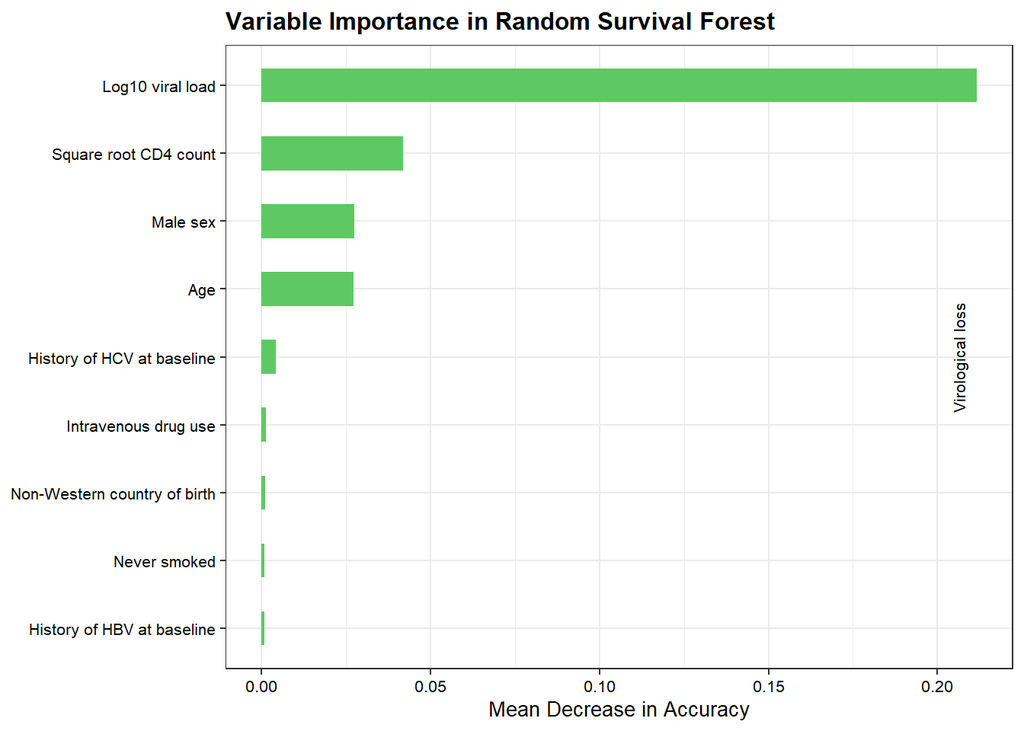

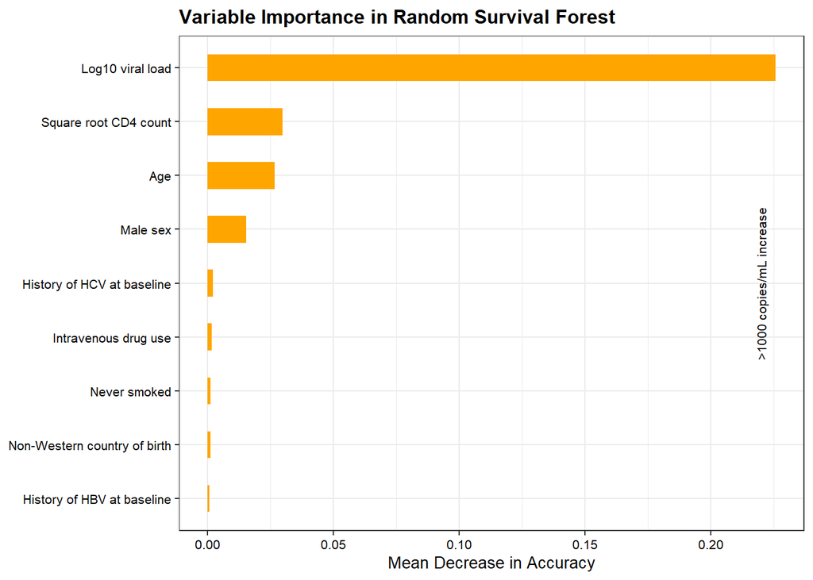

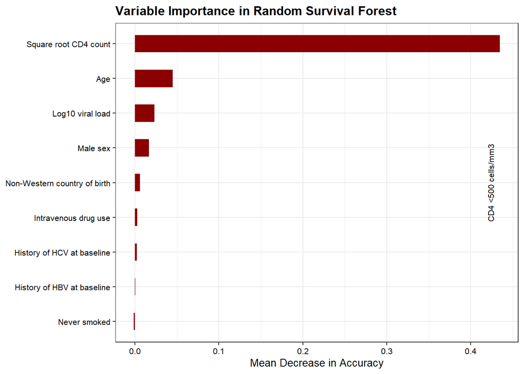

```r
# filter missing data (n=8)
train <- train %>% filter(!is.na(baseCD4_sqrt))

# Define features (predictors)
features <- c("MALESEX", "AGE",
              "SMOKING_NEVER","baseHCVever","baseHBVever",
              "IDU", "ORIGIN_NONWESTERN",
              "baseCD4_sqrt", "baseVL_log10")
# Define outcome measures
outcomes <- c("VL4K","HYBRID", "CD4")

# Define outcome measures
outcomes <- c("VL4K","HYBRID", "CD4")

meandecreaseaccuracy = list()

obtain_meandecreaseaccuracy <- function(outcome){
# Rename the data in train
  train <- train %>%
    mutate(time = .data[[paste0("TIME_", outcome)]],
           status = .data[[paste0("EVENT_", outcome)]]) %>%
    ## Only relevant for CD4LOSS: some do not have the outcome
    filter(!is.na(status))

  test <- test %>%
    mutate(time = .data[[paste0("TIME_", outcome)]],
           status = .data[[paste0("EVENT_", outcome)]]) %>%
    ## Only relevant for CD4LOSS: some do not have the outcome
    filter(!is.na(status))


  # train the RSF, random survival forest
  formula_model <- as.formula(paste("Surv(time, status) ~", paste(features, collapse = " + ")))
  rsfmodel <- rfsrc(formula_model, data = train, ntree = 1000, cv.fold = 10, nodesize = 65, mtry = 4, splitrule = "logrankscore", nsplit = 10)

importance_df <- tibble(
  Outcome = outcome,
  Variable = names(vimp(rsfmodel)$importance),
  MeanDecreaseAccuracy = vimp(rsfmodel)$importance
  )

meandecreaseaccuracy[[outcome]] <- importance_df
return(meandecreaseaccuracy)
}

# Make a list of all results
for (outcome in outcomes){
  meandecreaseaccuracy <- obtain_meandecreaseaccuracy(outcome)
}

# Perform cleaning operations on the list
for (outcome in outcomes){
  meandecreaseaccuracy[[outcome]] <- meandecreaseaccuracy[[outcome]] %>%
    mutate(
      Outcome = factor(
        Outcome,
        levels = c("VL4K", "HYBRID", "CD4"),
        labels = c("Virological loss",
                   ">1000 copies/mL increase",
                   "CD4 <500 cells/mm3")),
      Variable = factor(
        Variable,
        levels = c("AGE", "MALESEX", "baseBMI", "ORIGIN_NONWESTERN",
                   "SMOKING_NEVER", "IDU",
                   "baseHCVever", "baseHBVever",
                   "baseCD4_sqrt", "baseVL_log10"),
        labels = c("Age", "Male sex", "BMI", "Non-Western country of birth",
                  "Never smoked", "Intravenous drug use",
                  "History of HCV at baseline", "History of HBV at baseline",
                  "Square root CD4 count", "Log10 viral load"))
      )
}

# Create the ggplot
var_importance_plot <- function(outcome_index){
  i <- outcome_index
  data <- meandecreaseaccuracy[[outcomes[i]]]
  fillcolor <- c("#5ec962","orange","darkred")[i]
  g <- ggplot(data, aes(x = reorder(Variable, MeanDecreaseAccuracy, .desc = TRUE), y = MeanDecreaseAccuracy)) +
  geom_bar(stat = "identity", fill = fillcolor, width = 0.5) +
  coord_flip() +
  labs(title = "Variable Importance in Random Survival Forest",
       x = "Variables",
       y = "Mean Decrease in Accuracy") +
  theme_bw() +
  theme(strip.placement = "outside",
     strip.text = element_text(angle = 0, size = 8),
     strip.background = element_blank(),
     axis.text = element_text(size = 8, color = "black"),
     axis.title.y = element_blank(),
     axis.title.x = element_text(size = 10),
     plot.title = element_text(size = 12, face = "bold")) +

    annotate("text", x = 5, y = max(data$MeanDecreaseAccuracy),
             angle = 90, size = 8 / .pt, vjust = -1,
             label = meandecreaseaccuracy[[outcomes[i]]]$Outcome[1])

  print(g)
}

for (i in c(1:length(outcomes))){
  ggsave(paste0(outputdir, "VariableImportanceRSF_", outcomes[i], ".pdf"),var_importance_plot(i),width = 21/2, height = 29.7/6, units = "cm")

}
```

# Test performance of the models with the test datasets

Here I make a function to obtain the risk scores of the model, called obtain_scores(), which is used in another function, called obtain_auc(). The function obtain_auc() also runs the coxph() model for each outcome.

```r
# Remove those in train with missing CD4 at baseline (there are no missing in the test)
train <- train %>% filter(!is.na(baseCD4_sqrt))

# Define features (predictors)
features <- c("MALESEX", "AGE",
              "SMOKING_NEVER","baseHCVever","baseHBVever",
              "IDU", "ORIGIN_NONWESTERN",
              "baseCD4_sqrt", "baseVL_log10")
# Define outcome measures
outcomes <- c("VL4K","HYBRID", "CD4")

# Specify time points of interest to measure AUC
times <- seq(2, 8) * 365

# Define function to get score result
## This function will be used in the function obtain_auc below
obtain_scores <- function(models_list, dataset, survformula, traintest){
  score_result <- Score(models_list,
        formula = survformula,
        data = dataset,
        metrics = "auc",
        summary = "risks",
        times = times)
  AUC_overtime <- score_result$AUC$score
  AUC_overtime$type <- traintest

  return(AUC_overtime)
}

# Define function to get the AUC over time
obtain_auc <- function(outcome){

  # Rename the data in train
  train <- train %>%
    mutate(time = .data[[paste0("TIME_", outcome)]],
           status = .data[[paste0("EVENT_", outcome)]]) %>%
    ## Only relevant for CD4LOSS: some do not have the outcome
    filter(!is.na(status))

  test <- test %>%
    mutate(time = .data[[paste0("TIME_", outcome)]],
           status = .data[[paste0("EVENT_", outcome)]]) %>%
    ## Only relevant for CD4LOSS: some do not have the outcome
    filter(!is.na(status))

  # Check that the data is the same
  print("status" %in% colnames(train))
  print("status" %in% colnames(train))
  print(sum(train$time != train[,paste0("TIME_", outcome)]))
  print(sum(train$status != train[,paste0("EVENT_", outcome)]))
  print(sum(test$time != test[,paste0("TIME_", outcome)]))
  print(sum(test$status != test[,paste0("EVENT_", outcome)]))

  # Train the cox model
  features_cox <- c("MALESEX", "AGE","baseCD4_sqrt", "baseVL_log10")
  formula_cox <- as.formula(paste("Surv(time, status) ~", paste(features_cox, collapse = " + ")))
  coxmodel <- coxph(formula_cox, train, x = TRUE)

  # Define the formula for other models
  formula_model <- as.formula(paste("Surv(time, status) ~", paste(features, collapse = " + ")))

  # Train the elastic-net (balanced) penalized cox model
  elasticnetcox_model <- GLMnet(
    formula = formula_model,
    data = train,
    alpha = optimal_alpha_value[outcome],
    lambda = NULL,
    cv = TRUE,
    nfolds = 10,
    standardize = TRUE)

  # train the RSF, random survival forest
  rsfmodel <- rfsrc(formula_model, data = train, ntree = 1000, cv.fold = 10, nodesize = 65, mtry = 4, splitrule = "logrankscore", nsplit = 10)

  # Fit a GBM model with survival data
  gbm_model <- gbm(
      formula = Surv(time, status) ~ MALESEX + AGE + IDU + ORIGIN_NONWESTERN +
      SMOKING_NEVER + baseHCVever + baseHBVever +
      baseVL_log10 + baseCD4_sqrt,  # Survival formula
      data = train,
      distribution = "coxph",                    # Cox model for survival
      n.trees = 500,                           # Number of trees
      interaction.depth = 4,                   # Tree depth
      shrinkage = 0.05,                        # Learning rate
      n.minobsinnode = 15,                      # Minimum observations in terminal nodes
      bag.fraction = 0.5 # fraction of training data used for fitting, default 0.5
  )

  # Calculate AUC data over time for train and test
  survformula <- as.formula(paste("Surv(time, status) ~ 1"))
  model_list <- list("Cox" = coxmodel,
                     "RSF" = rsfmodel,
                     "ElasticNetCox" = elasticnetcox_model,
                     "GBM" = gbm_model)
  auc_train <- obtain_scores(model_list, train, survformula, "train")
  auc_test <-  obtain_scores(model_list, test, survformula, "test")

  auc_combined <- rbind(auc_train, auc_test)
  auc_combined$outcome <- outcome

  return(auc_combined)
}

# Apply the function to each outcome
auc_data <- map_dfr(outcomes, obtain_auc)
```

```
## [1] TRUE
## [1] TRUE
## [1] 0
## [1] 0
## [1] 0
## [1] 0
## [1] TRUE
## [1] TRUE
## [1] 0
## [1] 0
## [1] 0
## [1] 0
## [1] TRUE
## [1] TRUE
## [1] 0
## [1] 0
## [1] 0
## [1] 0
```

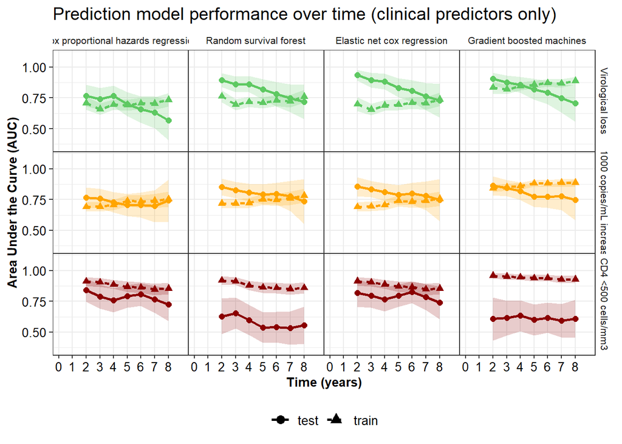

```r
# add nice labels for model and outcome
auc_data <- auc_data %>% mutate(
  model = factor(
    model, levels = c("Cox",
                      "RSF",
                      "ElasticNetCox",
                      "GBM"),
    labels = c("Cox proportional hazards regression",
               "Random survival forest",
               "Elastic net cox regression",
               "Gradient boosted machines")),
  outcome = factor(outcome,
    levels = c("VL4K", "HYBRID", "CD4"),
    labels = c("Virological loss", ">1000 copies/mL increase", "CD4 <500 cells/mm3")))

# Plot AUC over time with confidence intervals
## The plot should facetgrid on model on the x-axis and outcome on the y-axis.
## outcome determines color and fill. type determines shape and linetype and group.
auc_plot <- ggplot(auc_data, aes(x = times, y = AUC, group = type)) +
  geom_line(aes(linetype = type, color = outcome), linewidth = 1) +
  geom_point(aes(shape = type, color = outcome), size = 2) +
  geom_ribbon(aes(ymin = lower, ymax = upper, fill = outcome), alpha = 0.2) +
  labs(x = "Time (years)",
       y = "Area Under the Curve (AUC)",
       title = "Prediction model performance over time (clinical predictors only)") +
  theme_bw() +
  scale_colour_manual(values=(c("#5ec962","orange","darkred"))) +
  scale_fill_manual(values=(c("#5ec962","orange","darkred"))) +
  scale_y_continuous(limits = c(0.35, 1.1),
    breaks = c(0.5, 0.75, 1.0)) +
  scale_x_continuous(limits = c(0, 9*365),
    breaks = seq(0, max(auc_data$times), by = 365),
    labels = function(x) round(x / 365, 1)
  ) +
  facet_grid(outcome ~ model) +
  theme(strip.placement = "outside",
     strip.text= element_text(angle = 0, size = 8),
     strip.background = element_blank(),
     axis.text = element_text(size = 10, color="black"),
     axis.title = element_text(size = 10, color="black", face = "bold"),
     title = element_text(size=12, color = "black"),
     legend.text = element_text(size = 10, color="black"),
     legend.title = element_blank(),
     legend.position = "bottom",
     plot.subtitle = element_text(size = 10, color= "black", face="italic"),
     #legend.key.height = unit(1.5,'cm'),
     panel.grid.minor.x = element_blank(),
     panel.spacing = unit(0, "mm")) +

  # keep the type legend, but remove the outcome legend
    guides(fill = "none", color = "none", shape = guide_legend(override.aes = list(size=3))) # Remove outcome legend

print(auc_plot)
```

```r
ggsave(paste0(outputdir,"AUC_clinicalpredictorsonly.pdf"), plot = auc_plot, width = 210, height = 297/2, units = "mm")
```

## Create ROC curves for the models with the test datasets

```r
# roc_plot <- ggplot(roc_data, aes(x = FP, y = TP, color = model, linetype = model)) +
#   geom_line(size = 1) +
#   geom_abline(intercept = 0, slope = 1, linetype = "dashed", color = "gray") +
#   facet_wrap(~ times) +
#   scale_color_brewer(palette = "Set1") +
#   labs(x = "False Positive Rate",
#        y = "True Positive Rate",
#        title = "ROC Curves for Random Survival Forest and Cox Model",
#        subtitle = paste("AUC at 60 months - RSF:",
#                         round(roc_data$AUC[roc_data$times == 60 & roc_data$model == "RSF"], 3),
#                         "Cox:",
#                         round(roc_data$AUC[roc_data$times == 60 & roc_data$model == "Cox"], 3))) +
#   theme_bw() +
#   coord_equal() +
#   theme(legend.position = "bottom")
#
# print(roc_plot)
```